# Lab 2 - Part 2 - Wind Triangle

Table of Contents

Introduction Setting Up Initialize Aircraft and Environment Calculate the Transforms Establish the Vectors Create Wind Triangle Vectors Drawing the Wind Triangle Solving for True Airpspeed, Angle-of-Attack, and Side-Slip Angle Sanity Check What to Submit:

## Introduction

The Wind Triangle is the graphical representation of the relationship between aircraft motion and wind.

It is a vector diagram with three vectors

- The AIR vector representing the motion of the aircraft through the airmass. It is described by the true airspeed and true heading.
- The WIND vector represents the motion of the airmass over the ground. It is described by wind speed and the wind direction. In the wind triangle, wind direction is notated by the direction the wind is blowing to.
- The GROUND vector representing the motion of the aircraft over the ground. It is described by the ground speed and ground track.

The wind triangle describes the relationships among the quantities used in air navigation. When two of the three vectors are known, the remaining vector can be solved for.

In our case, the most likely case is that we know the GROUND vector (measured by a GPS unit) and the WIND vector (measured from a weather station), and we can use this to solve for the AIR vector.

This relationship is often written as:

The AIR velocity is the difference between the GROUND velocity and the WIND velocity.

## Setting Up

In this example, we'll generate a Wind Triangle diagram, and use the airplane model for visualization.

Let's start by creating a new script and loading up the airplane. We'll use the airplane scale to convert to ft, but we may opt to adjust this value later on.

```matlab
clear
clc
close all


load Lab_Airplane.mat
airplane_scale = 3.28;
airplane = airplane*airplane_scale;
```

## Initialize Aircraft and Environment

Next, we'll define our aircraft's orientation

```matlab
psi = 20;
theta = -1;
phi = 0;
```

Next, we'll define our aircraft's BODY velocities

```matlab
u = 57;
v = 0;
w = 0;
```

Next, we'll define some wind conditions. Remember, the notation is that wind velocities are in the direction the wind is blowing to

```matlab
wind_north = 13;
wind_east = 0;
wind_down = 0;
```

## Calculate the Transforms

Given the aircraft's orientation, we can now calculate the transforms - both the Transform To BODY From Earth, and Transform To EARTH From BODY.

```matlab
T_2BFE = Transform_To_Body_From_Earth(psi,theta,phi);
T_2EFB = T_2BFE';
```

If we use the same functions from the Rotation Matrices example, we can calculate these transforms quickly.

We'll use to rotate our aircraft model into the right orientation.

```matlab
airplane = (T_2EFB*airplane')';
```

Notice that we first need to transpose the airplane variable in order to do the rotation, then we'll transpose it back so it can be drawn in Matlab.

## Establish the Vectors

In our next step, we'll form our vectors and resolve them in both the BODY and EARTH frames.

Let's start with and

```matlab
V_g_BODY = [u;v;w];
V_g_EARTH = T_2EFB*V_g_BODY;
```

The wind velocities are given in the EARTH frame. Convert them to the BODY frame.

```matlab
V_w_EARTH = [wind_north;wind_east;wind_down];
V_w_BODY = T_2BFE*V_w_EARTH;
```

Now we can solve for and

```matlab
V_air_EARTH = V_g_EARTH-V_w_EARTH;
V_air_BODY = V_g_BODY-V_w_BODY;
```

Notating the name and the reference frame within the variable makes it easy for us to ensure that we're working in the right reference frames.

## Create Wind Triangle Vectors

In the next step, we'll create our vectors - we'll write it out to make the relationships more apparent.

```matlab
V_g_trajectory_EARTH = [0,V_g_EARTH(1);
                        0,V_g_EARTH(2);
                        0,V_g_EARTH(3)];
```

This vector is written as the GROUND vector TRAJECTORY in the EARTH frame. This is to notate that the starting point is at the origin, and extends to the correct magnitude. We'll do the same for the AIR and WIND vectors.

```matlab
V_a_trajectory_EARTH = [0,V_air_EARTH(1);
                        0,V_air_EARTH(2);
                        0,V_air_EARTH(3)];
```

One note on the WIND vector - instead of starting at the origin, we'll start it at the end of the AIR vector - this will ensure we actually form a triangle.

```matlab
wind_trajectory_EARTH = [V_air_EARTH(1),V_air_EARTH(1)+V_w_EARTH(1);
                   V_air_EARTH(2),V_air_EARTH(2)+V_w_EARTH(2);
                   V_air_EARTH(3),V_air_EARTH(3)+V_w_EARTH(3)];
```

Technically, we did not need to solve V_a_EARTH+V_w_EARTH - by definition, this is equal to V_g_EARTH - but it's nice to see the math work out.

## Drawing the Wind Triangle

Now that we have all three vectors, we can draw them in Matlab. Use plot3 so we can capture the 3D nature of the vectors. For good measure, we'll add the aircraft. Don't forget that we need to flip both the Y and Z axes to get the coordinate system right. In this example, we've placed the plotting inside of a function to save space.

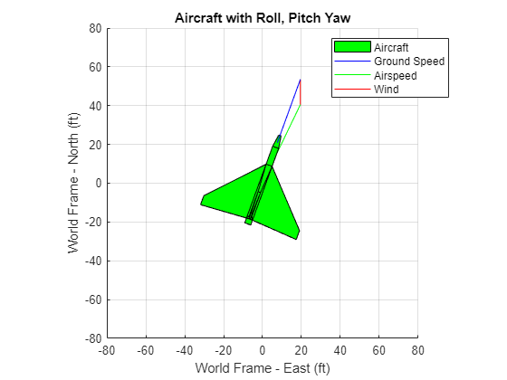

```matlab
plot_wind_triangle(f, airplane, V_g_trajectory_EARTH,V_a_trajectory_EARTH,wind_trajectory_EARTH);
```

## Solving for True Airpspeed, Angle-of-Attack, and Side-Slip Angle

Now that we have the AIR velocity, we can solve for the true airspeed , the angle-of-attack , and the side-slip angle .

Remember, we also have an AIR reference frame - which incorporates the rotations of and β. We have the following relationships

$V_{air|B} = \left( \matrix{ air_{u|B} \cr air_{v|B} \cr air_{w|B}} \right)=T_{B-A}\left(\matrix{V_{air}\cr 0 \cr 0}\right)$

$V_{air|B}=\left(\matrix{ \cos\beta\cos\alpha & -\sin\beta\cos\alpha & -\sin\alpha \cr \sin\beta & \cos\beta & -\sin\beta\sin\alpha \cr \cos\beta\sin\alpha & 0 & \sin\alpha\cos\beta} \right) \left(\matrix{V_{air}\cr 0 \cr 0}\right)$

$V_{air|B}=\left(\matrix{ air_{u|B} \cr air_{v|B} \cr air_{w|B}}\right) = \left(\matrix{ u_B-w_{u|B}\cr v_B-w_{v|B}\cr w_B-w_{w|B}}\right)$

$V_{air} = \sqrt{ \left(air_{u|B}\right)^2 + \left(air_{v|B}\right)^2 + \left(air_{w|B}\right)^2 }$

$\alpha = \tan^{-1}\left(\frac{air_{w|B}}{air_{u|B}}\right)$

$\beta = \sin^{-1}\left(\frac{air_{v|B}}{V_{air}}\right)$

We have already solved for , so we just have to plug the values into the last three equations.

```matlab
[V_air, alpha, beta] = wind_frame_calc(V_air_BODY);
disp(['Va: ',num2str(V_air), ' Alpha: ',num2str(rad2deg(alpha)),' Beta: ',num2str(rad2deg(beta))]);
```

Va: 45.0065 Alpha: 0.27275 Beta: 5.6696

## Sanity Check

It's important to always have a way to double check your work and make sure we fully grasp whether or not we programmed the equations correctly. We often call this a 'sanity check' - are our answers sane?

One simple way for us to check our equations is to plug in some numbers that are easy to check. The true airspeed is velocity of the aircraft moving through the airmass.

Consider the following scenarios:

- If our aircraft is flying North, and we have wind blowing North (flying with a tailwind), should the ground speed be faster or slower than the true airspeed?
- If our aircraft is flying South and we have wind blowing North (flying into the wind), should the ground speed be faster or slower than the true airspeed?
- If our aircraft is flight East and we have wind blowing North (flying crosswind), what direction should we be heading to ensure that we're compensating for the wind?

```matlab
disp(['True Airspeed: ',num2str(V_air),' Ground Speed: ',num2str(norm(V_g_EARTH)),' Wind Speed: ',num2str(norm(V_w_EARTH))]);
```

True Airspeed: 45.0065 Ground Speed: 57 Wind Speed: 13

## What to Submit:

- Copy of script to calculate V_air, alpha and beta
- Two (2) screenshots of the wind triangle with different wind speed/direction